# print(‘Hello, Brazil!’) - Uma Análise Quantitativa da Posse de Bolsonaro

Ariel Serranoni e Wilson dos Anjos

## Introdução

Durante períodos eleitorais, a discussão sobre métodos estatísticos sempre vem à tona devido à constante divulgação de pesquisas eleitorais. Em particular, a constante propagação de falácias pelo então candidato Jair Bolsonaro e a discrepância entre os resultados apontados pelas pesquisas e aqueles apurados nas urnas aumentaram muito a disconfiança sobre os métodos utilizados. Para mais detalhes a respeito da metodologia empregada em pesquisas eleitorais, recomendamos [este artigo](https://www.curso-r.com/blog/2018-08-31-eleitorais).

Aqui vamos expor o processo que percorremos ao realizar a análise contida [nesta série](https://www.linkedin.com/pulse/printhello-brazil-uma-an%C3%A1lise-do-discurso-de-posse-dos-anjos-junior). Para não deixar dúvidas aos mais desavisados, análise de texto não tem **NADA A VER** com pesquisas eleitorais. A potencialmente aparente semelhança que pode ter vindo à mente do leitor se deve somente ao contexto político em que métodos estatísticos estão sendo empregados. Claro, isso não implica que haja qualquer relação entre tais métodos.

Nossa intenção aqui é expor os resultados que obtivemos de uma maneira mais crua, tocando levemente em aspectos técnicos. Recomendamos o artigo para aqueles curiosos que leram algum dos nossos textos e também para quem quer usar o R para fins semelhantes. Sugerimos a ambos os grupos que façam o download do código, seja para fazer experimentos e extrair suas próprias conclusões a respeito dos discursos presidenciais ou ainda para examinar em maior detalhe os formatos-padrão de tabelas para bibliotecas importantes em análise de textos, como a `quanteda`, a `tidytext` e a `stm`.

## Quatro Princípios em Análise Automatizada de Textos

A ideia de analisar muitos textos simultaneamente parece muito atrativa aos olhos de quem tem gosto pela leitura. Isso se deve à ‘promessa’ de aumentar o número de leituras. Porém, a análise quantitativa de um texto não substitui sua leitura. Este [texto](https://web.stanford.edu/~jgrimmer/tad2.pdf) descreve algumas boas práticas para quem faz e também para quem interpreta análises quantitativas de textos. Colocamos para o leitor uma versão resumida dos 4 princípios apresentados na seção 2.

1.**Todos os Modelos Quantitativos de Linguagem Estão Errados - Mas Alguns são Úteis**: O processo de gerar dados em forma de texto é muito complicado e nem mesmo especialistas em linguística sabem ao certo como funcionam as estruturas de dependência nos, e entre os, diferentes níveis hierarquicos de um texto (capítulos, parágrafos, frases, palavras e etc). Entretanto, ainda conseguimos extrair informações e ideias úteis a partir de modelos quantitativos. Em suma, a qualidade do modelo é descrita pela sua capacidade de cumprir as tarefas para as quais é empregado

2.**Métodos Quantitativos Ajudam Humanos e Não os Substituem**: Métodos de análise quantitativa já demonstraram boa performance em uma grande variedade de problemas importantes. Contudo, tais técnicas não substituem o pensamento crítico e leitura cuidadosa feita pelos pesquisadores. De fato, conhecer a fundo os dados é essencial para se fazer uma boa análise

3.**Não Existe um Método Globalmente Ótimo para Análise de Texto**: Diferentes conjuntos de dados nos levam a diferentes perguntas, e cada pergunta merece atenção especial, sendo nescessárias técnicas e modelos (ou “famílias” destes) diferentes para cada propósito. O artigo citado acima também apresenta um resumo das técnicas usadas para alguns objetivos.

4.**Validar, Validar, Validar**: Esse princípio está muito relacionado à aplicação de modelos de machine learning para a análise de textos. Uma vez que não existe um método globalmente ótimo, é muito importante testar várias possibilidades e comparar seus desempenhos ao se fazer uma análise. É muito importante evitar usar resultados obtidos por um modelo não validado.

## Colocando a Mão na Massa - Importação e Tratamento dos Dados

O primeiro passo para toda e qualquer análise é importar dados para sua plataforma favorita. Aqui, vamos usar uma base coletada no site da [biblioteca do governo federal](http://www.biblioteca.presidencia.gov.br/publicacoes-oficiais). Ela consiste dos discursos de posse dos presidentes Fernando Henrique Cardoso, Luiz Inácio Lula da Silva e Dilma Roussef, cada um em seus dois mandatos, Michel Temer e Jair Bolsonaro. Toda a análise é feita utilizando o RStudio e os pacotes que são carregados a seguir:

```r
library(lexiconPT) # Análise de Sentimentos em português
library(tidyr) # formatação de dados
library(dplyr) # Tratamento dos gráficos
library(ggplot2) # Visualizações
library(igraph) # Fazer Grafos
library(ggraph) # Visualizar grafos no estilo ggplot
library(gridExtra) # Mostrando gráficos simultâneamente
library(tidytext) # Tratamento de texto (tabelas)
library(stringr) # Tratamento de texto (strings)
library(corpus) # StopWords
library(tm)
library(ggwordcloud) # Nuvens de palavras no estilo ggplot
library(knitr) # Markdown
library(kableExtra) # create a nicely formated HTML table
library(formattable) # for the color_tile function
library(tidyverse) # tudo de melhor para o R
library(forcats)
library(stm) # Modelagem de tópicos
library(quanteda) # Tratamento de texto
library(drlib) # função reorder... que é importante para a beleza dos gráficos
library(radarchart) # Gráficos radar
```

Iniciamos carregando a nossa base de dados, juntamente com outras tabelas que contém a traduções dos textos para a língua inglesa. Essas traduções serão importantes e uma lista de *stopwords*, que são palavras que ocorrem naturalmente muitas vezes em uma língua e assim acabam viesando este tipo de análise. Artigos como “a” e “o” e preposições como “de” e “para” são exemplos de palavras que tendem a aparecer muitas vezes em qualquer texto escrito em português.

```r
dados <- read.csv("dados.csv", stringsAsFactors = FALSE)[, -1]

names(dados) <- c("V1", "presver", "ano", "presidente")

traduc <- read.csv("traducao.csv", stringsAsFactors = FALSE)

trnlst <- read.csv("trnslt.csv", stringsAsFactors = FALSE)

stp_wrds <- corpus::stopwords_pt

traduc$translatedText[4] <- "come away, flame this dream"
```

Agora, vamos definir duas funções que serão nescessárias para o nosso trabalho. A primeira delas é projetada para o tratamento dos dados, colocando todas as palavras em letra minúscula para que não tenhamos distinções indesejadas. Além disso, removemos pontuações e outras “sujeiras” dos dados. A segunda função tem o propósito de substituir a função `bind_tf_idf` do pacote `tidytext`. Não ousaremos dizer que a função está errada sem olhar seu código, entretanto acreditamos que ela atribui TF-IDF zero para todas as palavras que aparecem em todos os documentos. Recomendamos que confiram seus resultados ao usar `bind_tf_idf`.

```r
extrai_palavras <- function(df, opt) {
  ## letra minuscula
  df[, 1] <- tolower(df[, 1])
  ## tira quebras de linha e stopwords
  for (i in seq_along(df$V1)) {
    df[i, 1] <- gsub("[\n“”–—]", " ", removeWords(df[i, 1], stp_wrds))
  }
  ## cria vetor de palavras
  palavras <- unlist(str_split(df$V1[1:NROW(df)], " +"))
  # tira pontuação
  palavras <- (removePunctuation(palavras))
  # tira espaços vazios
  palavras <- palavras[str_count(palavras) > 1]

  ## cria contagem
  if (opt == "count") {
    palavras_count <- table(palavras)

    return(palavras_count)
  }
  ## unique
  if (opt == "unique") {
    return(unique(palavras))
  }
}

## Função caseira para calcular o TF-IDF

tf_idf_caseirao <- function(tfrases) {
  tfrases <- tfrases %>% mutate(idf = 0)
  for (i in 1:nrow(tfrases)) {
    tfrases$idf[i] <- 1 / filter(tfrases, word == tfrases$word[i]) %>% nrow()
  }
  tfrases <- tfrases %>% mutate(tf_idf = n * idf)
}
```

Agora, usamos a função `extrai_palavras` para obter os data frames `tab_frase` e `tidyfrase`, que estão nos formatos ideais para trabalharmos com os pacotes necessários. Vamos usá-los em grande parte do trabalho.

**AVISO**: Abrir a tabela `tab_frase` pode travar seu computador!

```r
## TABELA TIDYFRASE
# fazendo a tabela de ocorrencias de palavras por frase

tab_frase <-
  data.frame(
    frases = unlist(str_split(dados[1, 1], "[.]")),
    stringsAsFactors = FALSE,
    doc = rep(dados$ano[1]),
    pres = rep(dados$presidente[1])
  )

for (i in 2:NROW(dados)) {
  tab_frase <- rbind(
    tab_frase,
    data.frame(
      frases = str_split(dados[i, 1], "[.]")[[1]],
      stringsAsFactors = FALSE,
      doc = rep(dados$ano[i]),
      pres = rep(dados$presidente[i])
    )
  )
}

tab_frase[, 1] <- removePunctuation(tab_frase[, 1])

aux <-
  matrix(0,
    nrow = nrow(tab_frase),
    ncol = length(extrai_palavras(dados, "unique"))
  )

names(aux) <- extrai_palavras(dados, "unique")

tab_frase <- cbind(tab_frase, aux)

names(tab_frase) <-
  c("frases", "docs", "presidas", extrai_palavras(dados, "unique"))

nomes <- names(tab_frase)

tab_frase[-c(163, 338, 548), ] # frases so com espaco

# contando as palavras por frase

for (i in seq_along(tab_frase[, 1])) {
  x <- as.data.frame(table(unlist(str_split(tab_frase[i, 1], " "))),
    stringsAsFactors = FALSE
  )[-1, ]

  for (j in seq_along(x[, 1])) {
    cnt_aux <- which(nomes == x[j, 1])

    tab_frase[i, cnt_aux] <- x[j, 2]
  }
}

tidyfrase <- tab_frase %>% select(frases, docs, presidas)
tidyfrase <- tidyfrase %>% mutate(nfrase = row_number())
tidyfrase <- tidyfrase %>% unnest_tokens(word, frases)
tidyfrase <- tidyfrase %>% filter(!(word %in% stp_wrds))


# pode ser feito direto com dados tb!
un_frases <- tab_frase %>%
  unnest_tokens(word, frases) %>%
  count(docs, word, sort = TRUE)

# find the words most distinctive to each document
tf_frases <- un_frases %>%
  bind_tf_idf(word, docs, n) %>%
  arrange(desc(tf_idf))
```

## Primeiras Vizualizações - Nuvens de Palavras

Agora vamos iniciar nosso passeio pelos dados. O caminho que iremos tomar é de fora para dentro. Isto é, começamos respondendo perguntas simples como “Quantas palavras diferentes foram ditas em cada fala?” e depois buscaremos respostas para, por exemplo, “Como medir a similaridade entre dois textos?” e “Quais são os tópicos predominantes em discursos presidenciais?”.

Começamos com nuvens de palavras mostrando as 30 palavras mais faladas em cada um dos discursos que analisaremos. Observe que, sem os títulos em cada gráfico, fica difícil capturar as diferenças entre os discursos. Parece que existem palavras, como “povo”, “Brasil” e “país” são quase obrigatóriamente repetidas muitas vezes no discurso inaugural de um presidente.

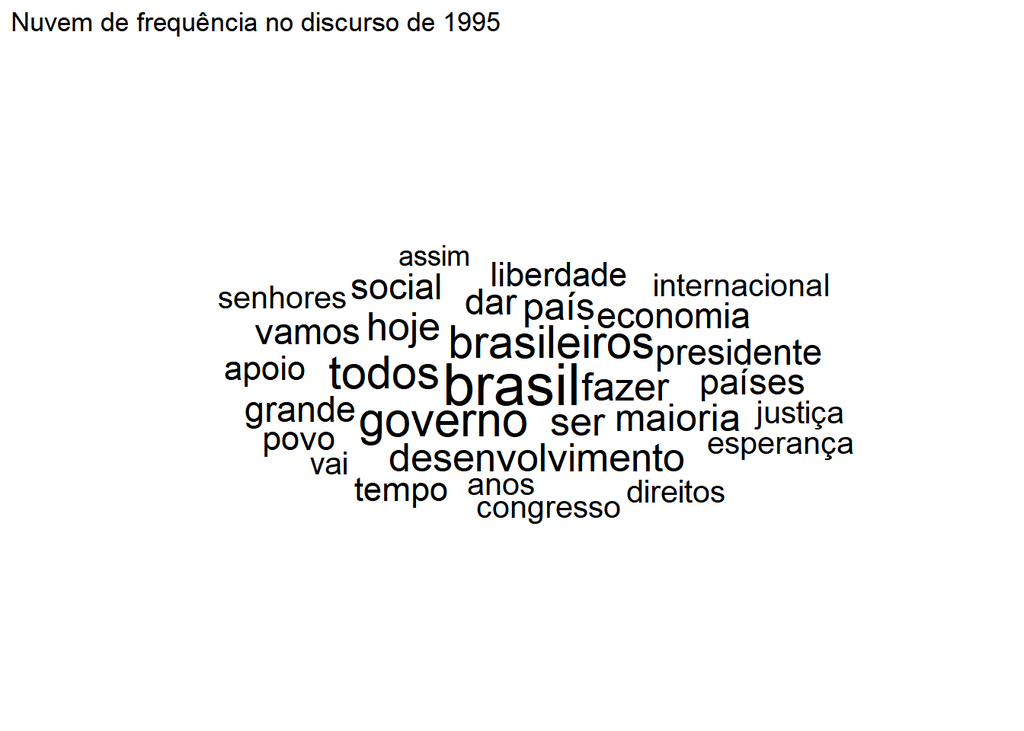

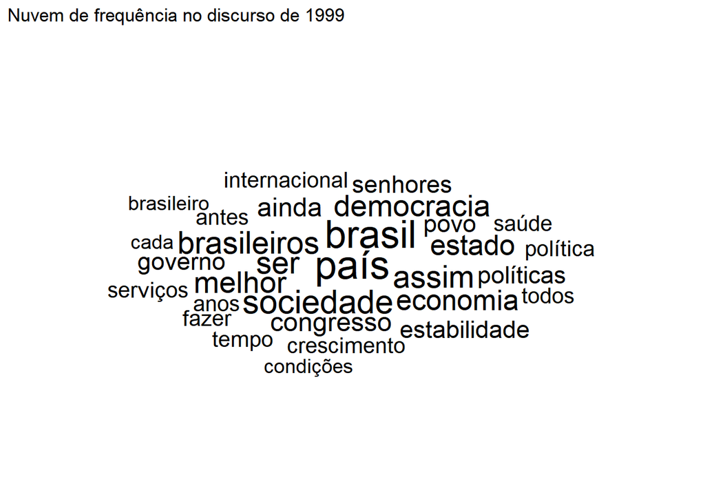

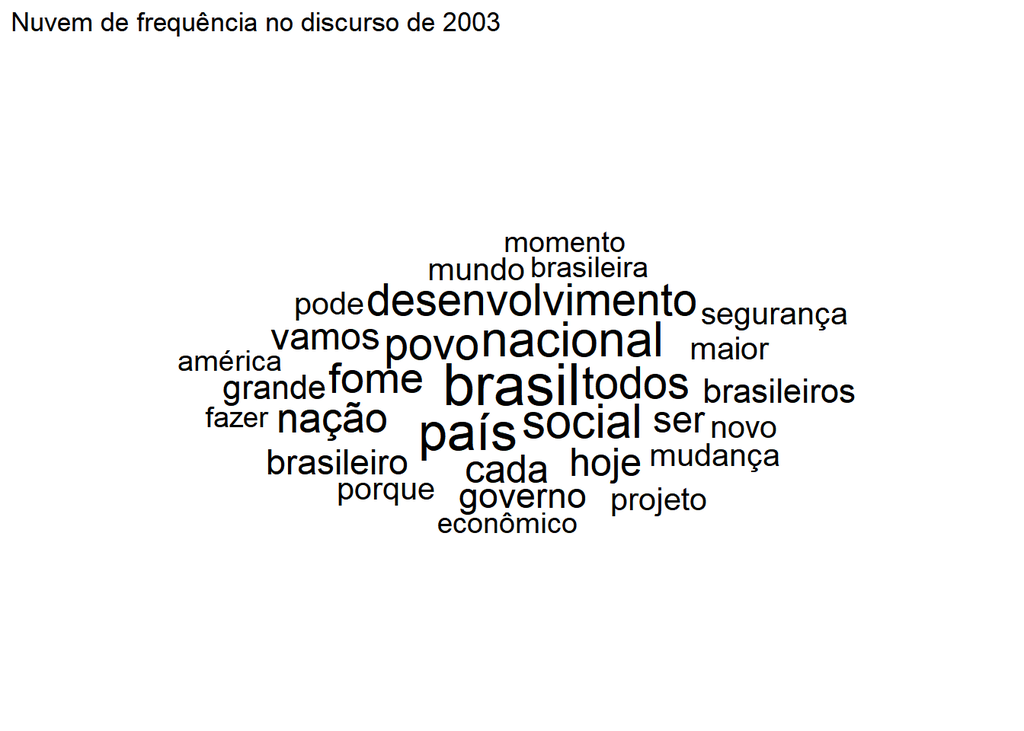

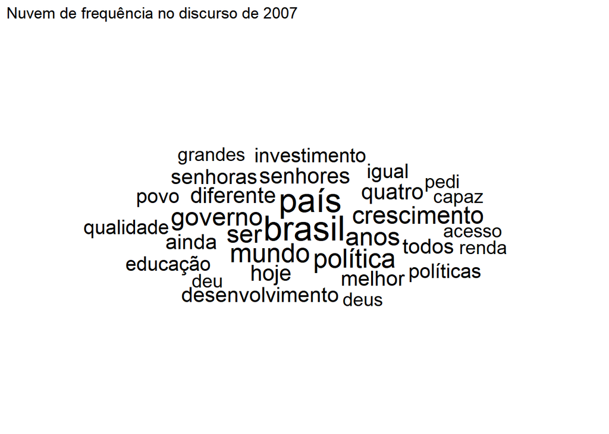

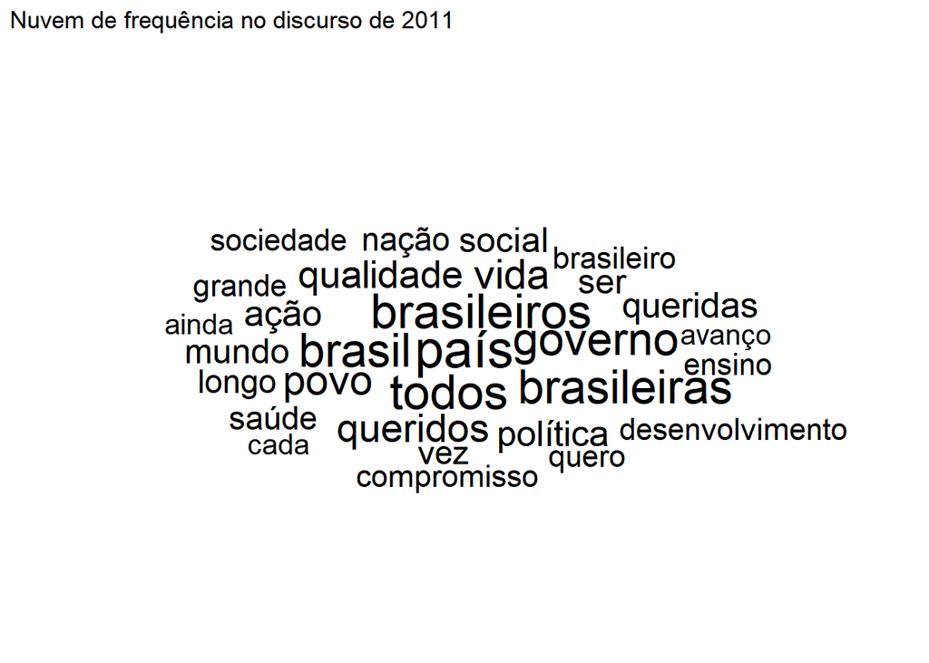

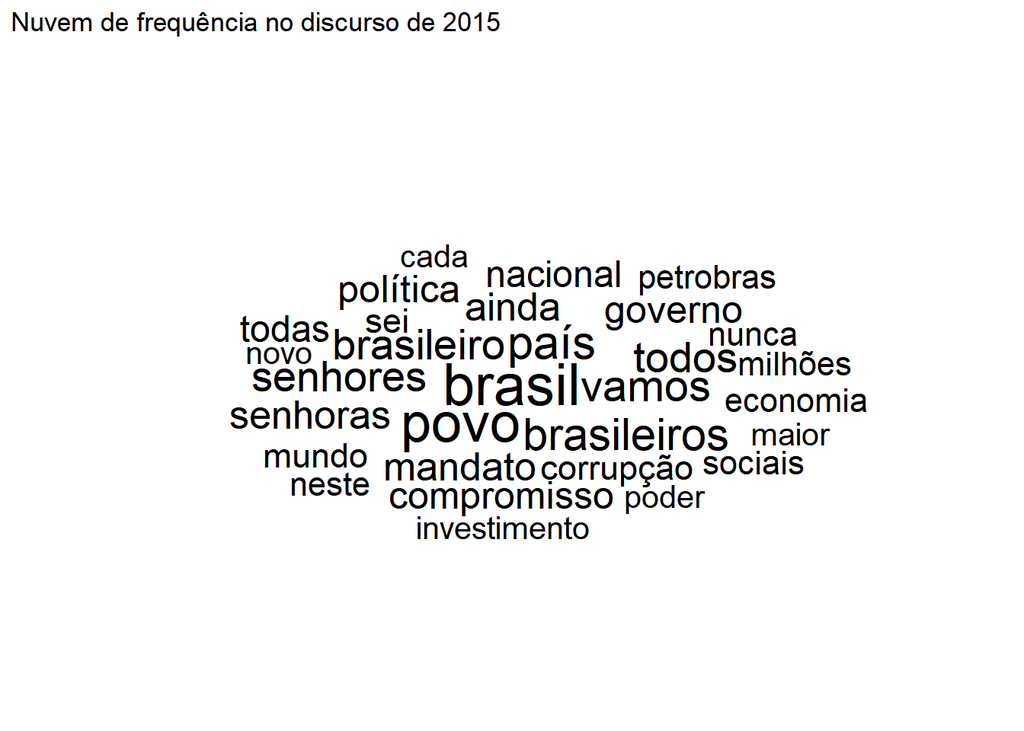

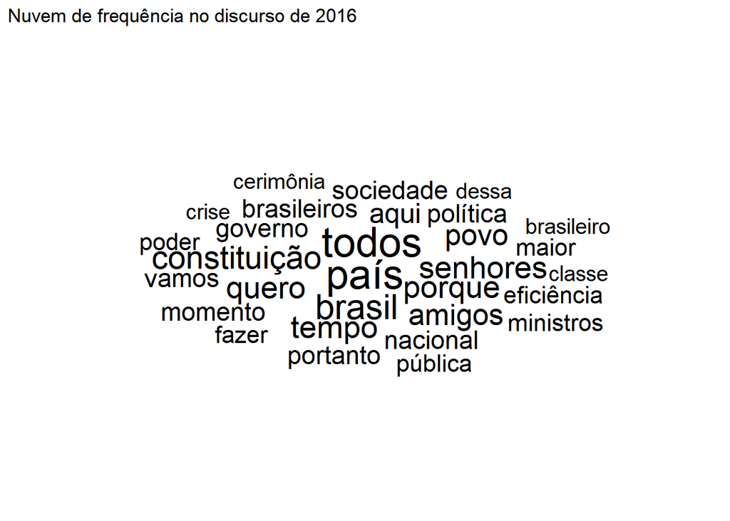

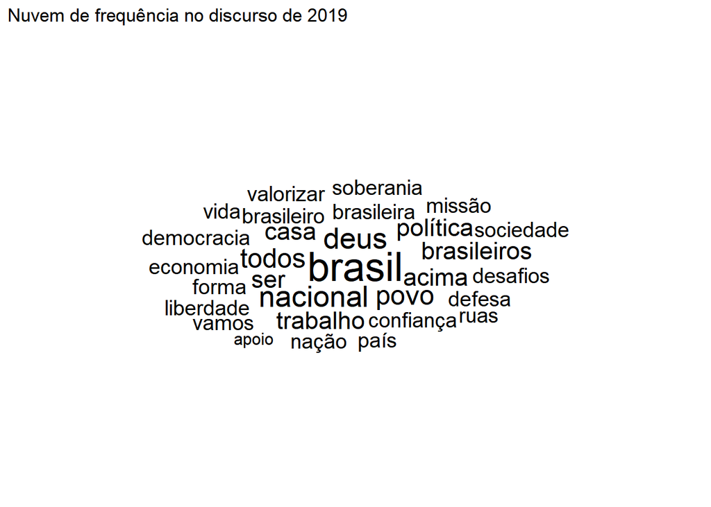

```r
# BASEADA NA FREQUENCIA

for (i in 1:nrow(dados)) {
  aux <- arrange(as.data.frame(extrai_palavras(dados[i, ], "count")), desc(Freq))
  (ggplot(aux[1:30, ], aes(label = palavras, size = Freq)) +
    geom_text_wordcloud() +
    scale_size_area(max_size = 10) +
    ggtitle(paste("Nuvem de frequência no discurso de", as.character(dados$ano[i]), sep = " ")) +
    theme_minimal()) %>% print()
}
```

Os próximos gráficos também são nuvens de palavras, porém carregam diferenças em relação às vizualizações anteriores. A primeira delas é a função utilizada. Embora sejam ambas da biblioteca `ggwordcloud`, a primeira se comporta como uma opção para o *layer* `geom` do pacote `ggplot2` e se encaixa perfeitamente com os outros recursos desse pacote. Enquanto isso, a função `ggwordcloud2` tem o intuito de produzir resultados similares aos obtidos usando o pacote `wordcloud2`. Além disso, no ’*chunk* acima usamos o ranqueamento de uma palavra com relação à frequência para determinar se uma palavra apareceria ou não na nuvem de palavras. Abaixo, o critério é outro. Calculamos a média e o desvio padrão da frequência de palavras no texto e escolhemos as palavras com frequência maior ou igual à média mais duas vezes o desvio padrão.

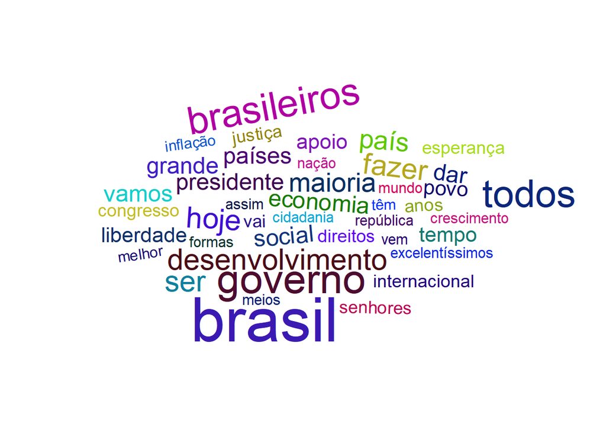

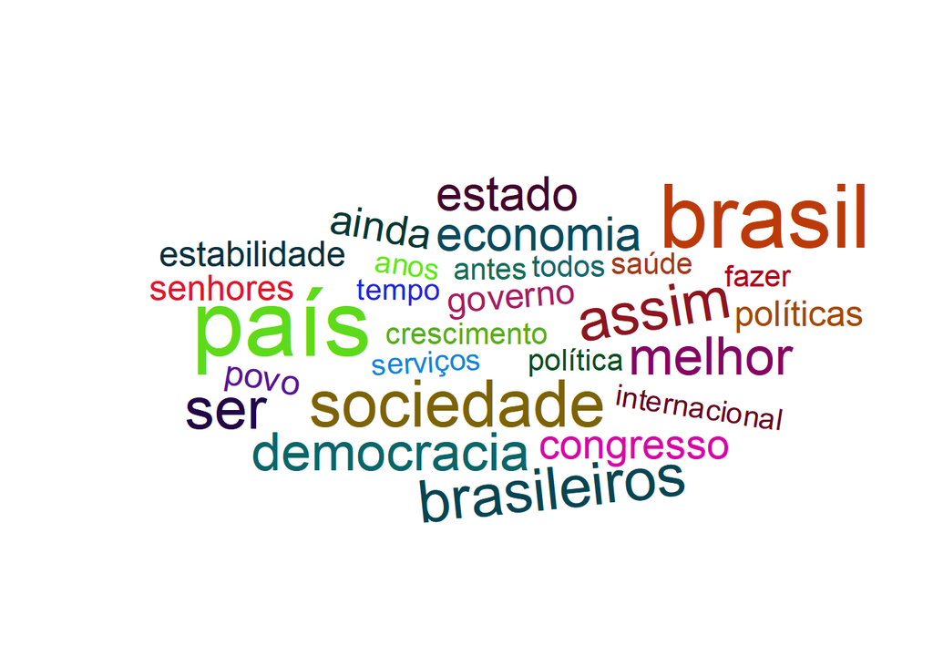

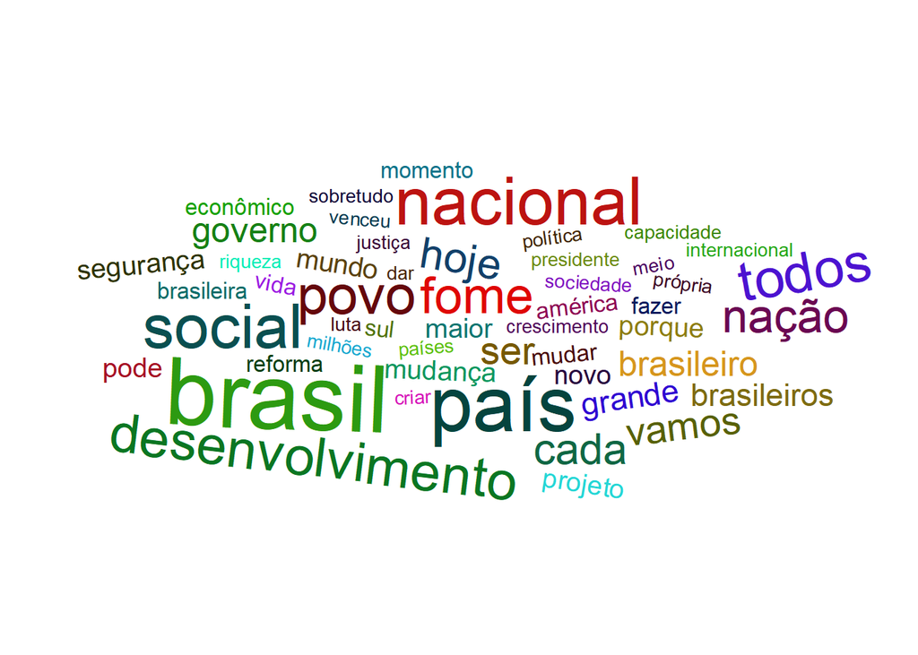

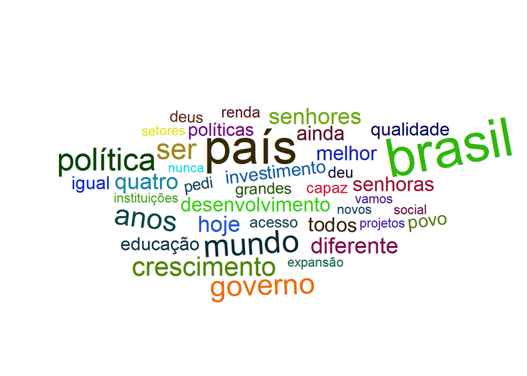

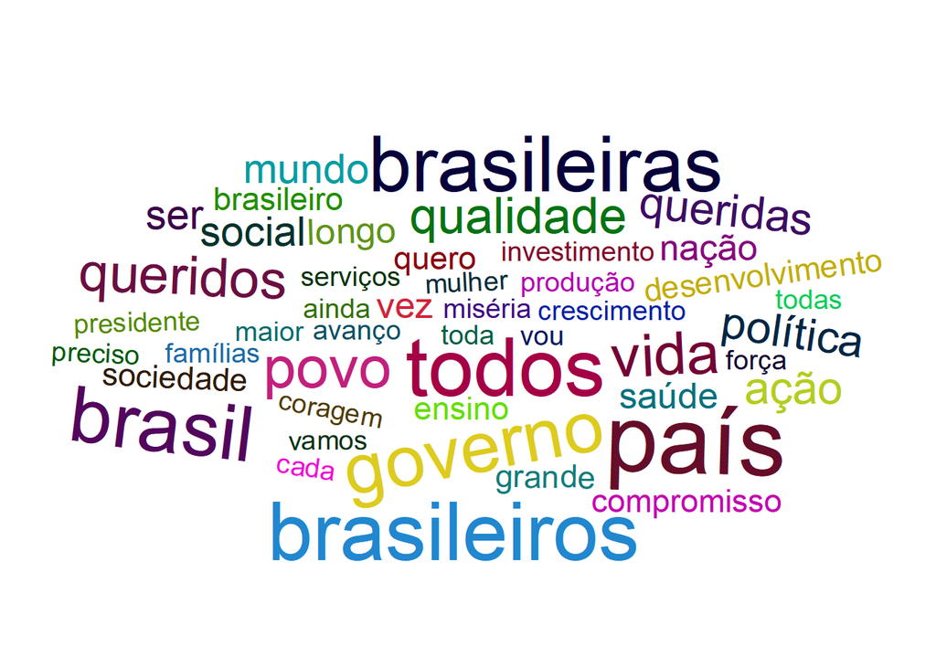

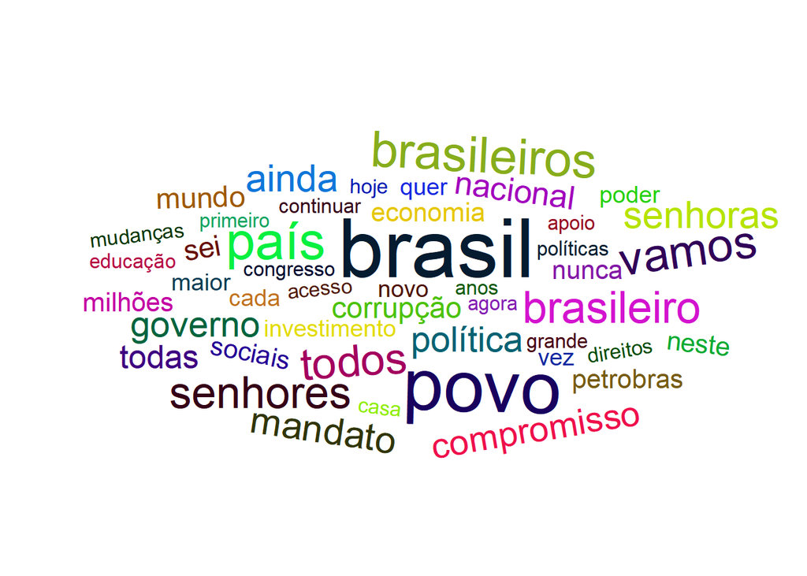

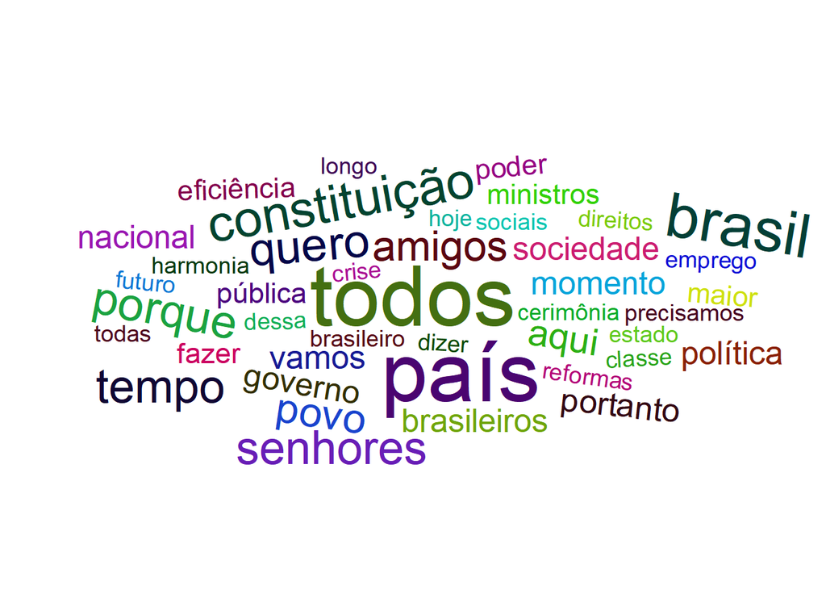

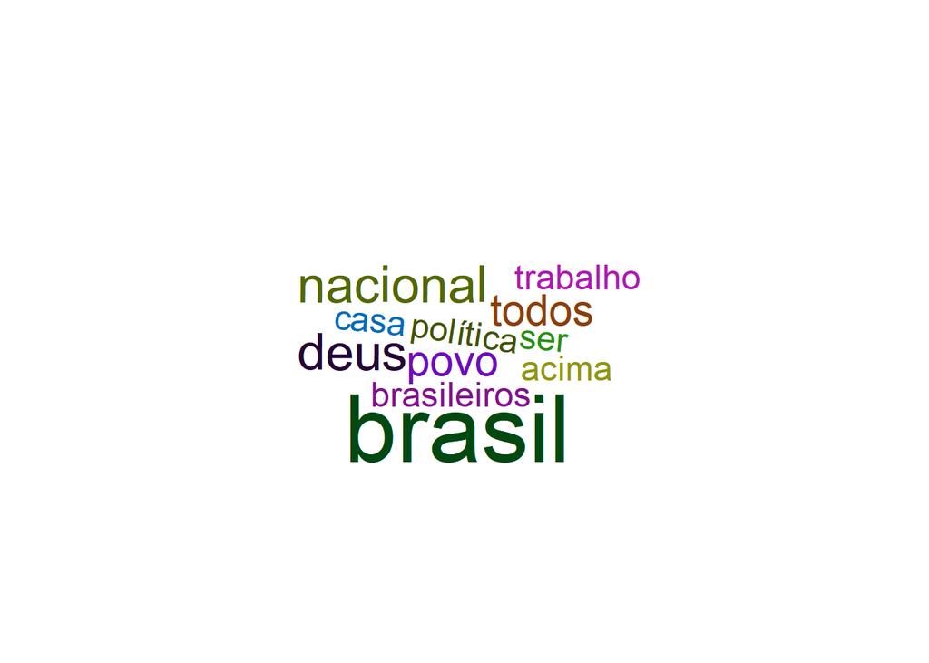

```r
## Nuvem - desvio padrão

for (i in 1:nrow(dados)) {
  aux <- arrange(as.data.frame(extrai_palavras(dados[i, ], "count")), desc(Freq))
  med <- mean(aux$Freq)
  sd <- sd(aux$Freq)
  aux <- aux %>% filter(Freq - med > 2 * sd)
  ggwordcloud2(aux) %>% print()
}
```

## Mil Jeitos de Contar Palavras

As tabelas a seguir apresentam algumas medidas referentes ao número de palavras faladas em cada discurso e por cada presidente. A coluna `num_words` apresenta o número total de palavras em cada instância. Além disso, a coluna `uniq` apresenta o número de palavras distintas em cada contexto e a coluna `stp` contém o número de *stopwords*. Finalmente, a coluna `rep` contém a razão `uniq`/`num_words`. De certa forma, o resultado dessa conta mede a variedade linguística em um documento.

Pela primeira vez, estamos dividindo a análise em duas perspectivas. Comparação por discursos ou presidentes. Esses dois tipos de abordagem vão ser amplamente aplicados daqui pra frente, às vezes dando lugar a um olhar mais geral. Aqui é importante destacar que para alguns fins, será importante duplicar as medidas em relação aos presidentes Temer e Bolsonaro, pois estes tiveram apenas um discurso de posse, enquanto FHC, Lula e Dilma tiveram dois.

De maneira simplificada, a nescessidade de duplicar as estatísticas de Temer e Bolsonaro é dada pelas comparações que fazemos. Por exemplo, num contexto em que estamos verificando quais palavras foram mais faladas por CADA presidente, essa ‘gambiarra’ não é nescessária pois, de qualquer maneira, a ordenação dessas estatísticas seria a mesma e a diferença entre elas proporcional. Por outro lado, num contexto em que investigamos quantas vezes cada presidente falou uma determinada palavra, aí sim é indispensável que alteremos as estatísticas para preservar a justiça na comparação ENTRE presidentes.

Uma outra alternativa para lidar com o problema da comparação ENTRE presidentes seria calcular a frequência relativa de uma palavra nas falas de um presidente, assim, a potencial maior ocorrência das palavras ditas por Lula, Dilma e FHC se ‘dissolve’ no maior número total de palavras ditas pelos mesmos.

```r
# contagem total de palavras sem retirar stopwords
full_word_count <- dados %>%
  unnest_tokens(word, V1) %>%
  group_by(ano) %>%
  summarise(num_words = n(), uniq = length(unique(word)), stp = length((word %in% stp_wrds)[word %in% stp_wrds == TRUE]), rep = length(unique(word)) / n()) %>%
  arrange(desc(num_words))

full_word_count %>%
  ungroup(num_words, ano) %>%
  mutate(num_words = color_tile("white", "lightgray")(num_words)) %>%
  mutate(stp = color_tile("white", "lightpink")(stp)) %>%
  mutate(uniq = color_tile("white", "lightblue")(uniq)) %>%
  mutate(rep = color_tile("white", "lightgreen")(rep)) %>%
  kable("html", escape = FALSE, align = "c", caption = "Total de Palavras por Discurso") %>%
  kable_styling(
    bootstrap_options =
      c("striped", "condensed", "bordered"),
    full_width = FALSE
  )
```

Total de Palavras por Discurso

| ano | num_words | uniq | stp | rep |
| --- | --- | --- | --- | --- |
| 2015 | 4561 | 1468 | 1994 | 0.3218592 |
| 2003 | 3883 | 1440 | 1721 | 0.3708473 |
| 2007 | 3755 | 1347 | 1636 | 0.3587217 |
| 2011 | 3617 | 1231 | 1574 | 0.3403373 |
| 1995 | 3266 | 1227 | 1485 | 0.3756889 |
| 2016 | 2744 | 1017 | 1231 | 0.3706268 |
| 1999 | 2633 | 1044 | 1215 | 0.3965059 |
| 2019 | 990 | 489 | 446 | 0.4939394 |

```r
# contagem total de palavras sem retirar stopwords
full_word_count <- dados %>%
  unnest_tokens(word, V1) %>%
  group_by(presidente) %>%
  summarise(num_words = n(), uniq = length(unique(word)), stp = length((word %in% stp_wrds)[word %in% stp_wrds == TRUE]), rep = length(unique(word)) / n()) %>%
  arrange(desc(num_words))


full_word_count %>%
  ungroup(num_words, presidente) %>%
  mutate(num_words = color_tile("white", "lightgray")(num_words)) %>%
  #  mutate(presidente = color_bar("lightgray")(presidente)) %>%
  mutate(stp = color_tile("white", "lightpink")(stp)) %>%
  mutate(uniq = color_tile("white", "lightblue")(uniq)) %>%
  mutate(rep = color_tile("white", "lightgreen")(rep)) %>%
  kable("html", escape = FALSE, align = "c", caption = "Total de Palavras por Presidente") %>%
  kable_styling(
    bootstrap_options =
      c("striped", "condensed", "bordered"),
    full_width = FALSE
  )
```

Total de Palavras por Presidente

| presidente | num_words | uniq | stp | rep |
| --- | --- | --- | --- | --- |
| dilma | 8178 | 2165 | 3568 | 0.2647347 |
| lula | 7638 | 2251 | 3357 | 0.2947107 |
| fhc | 5899 | 1898 | 2700 | 0.3217494 |
| temer | 2744 | 1017 | 1231 | 0.3706268 |
| bolsonaro | 990 | 489 | 446 | 0.4939394 |

Agora que já sabemos quantas palavras foram ditas nas ocasiões estudadas e temos uma idéia sobre a quantidade de repetição em cada uma, vamos reconhecer que ainda não sabemos quase nada sobre o que de fato foi dito. Em seguida, queremos ter uma visão geral sobre o comprimento das palavras utilizadas. Para isso, comparamos as distribuições dessa quantidade no geral, em cada discurso, de cada presidente, e na língua portuguesa. Obtivemos uma aproximação para a distribuição geral na língua através dos dados `sentiLex_lem_PT02` que estão disponíveis juntamente com o pacote `lexiconPT`.

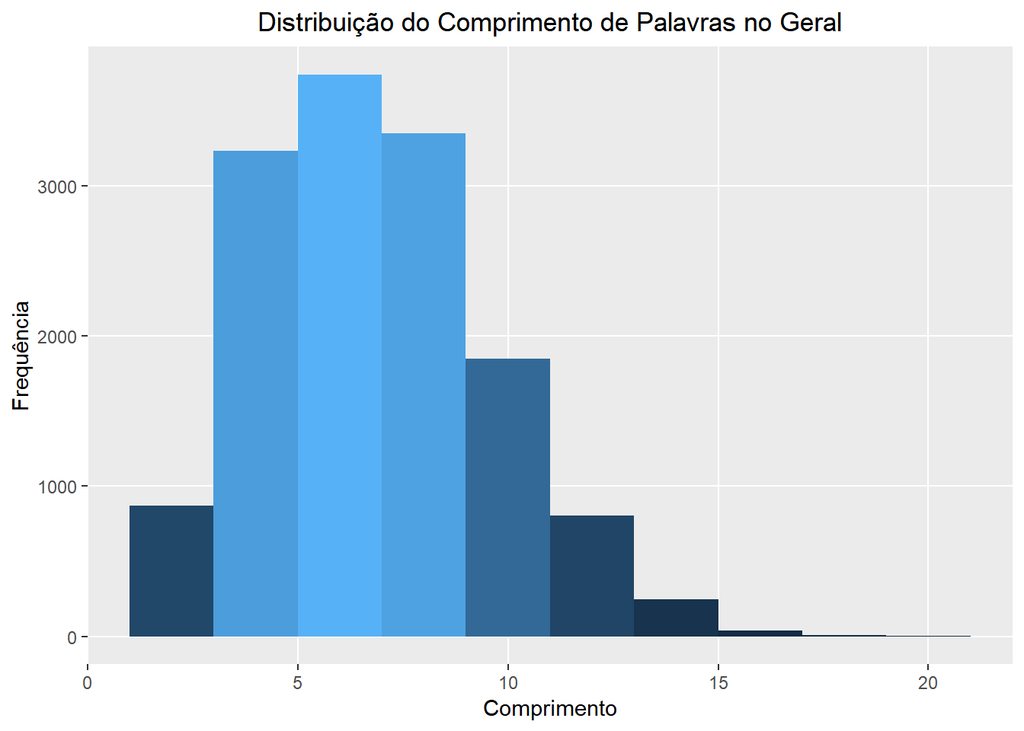

```r
#####################

# word length dist

word_lengths <- dados %>%
  unnest_tokens(word, V1) %>%
  mutate(word_length = nchar(word)) %>%
  filter(!(word %in% stp_wrds))

word_lengths %>%
  ggplot(aes(word_length),
    binwidth = 1
  ) +
  geom_histogram(aes(fill = ..count..),
    breaks = seq(1, max(word_lengths$word_length), by = 2),
    show.legend = FALSE
  ) +
  labs(x = "Comprimento", y = "Frequência") +
  ggtitle("Distribuição do Comprimento de Palavras no Geral") +
  theme(
    plot.title = element_text(hjust = 0.5),
    panel.grid.minor = element_blank()
  )
```

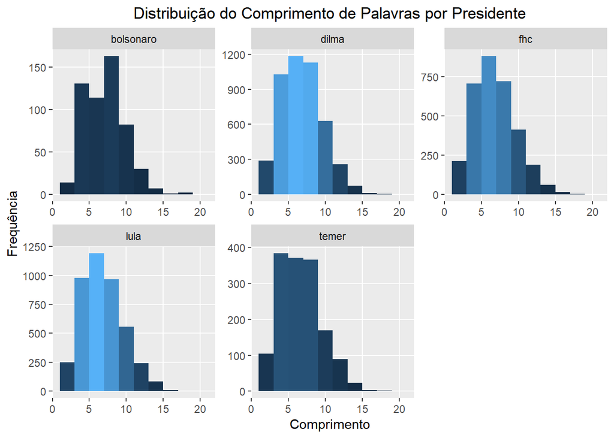

```r
#####################

# word length dist por presidente


word_lengths %>%
  ggplot(aes(word_length, fill = presidente),
    binwidth = 1
  ) +
  geom_histogram(aes(fill = ..count..),
    breaks = seq(1, max(word_lengths$word_length), by = 2),
    show.legend = FALSE
  ) +
  facet_wrap(~presidente, scales = "free", labeller = labeller(presidas = c(bolsonaro = "Bolsonaro", dilma = "Dilma", fhc = "FHC", lula = "Lula", temer = "Temer"))) +
  labs(x = "Comprimento", y = "Frequência") +
  ggtitle("Distribuição do Comprimento de Palavras por Presidente") +
  theme(
    plot.title = element_text(hjust = 0.5),
    panel.grid.minor = element_blank()
  )
```

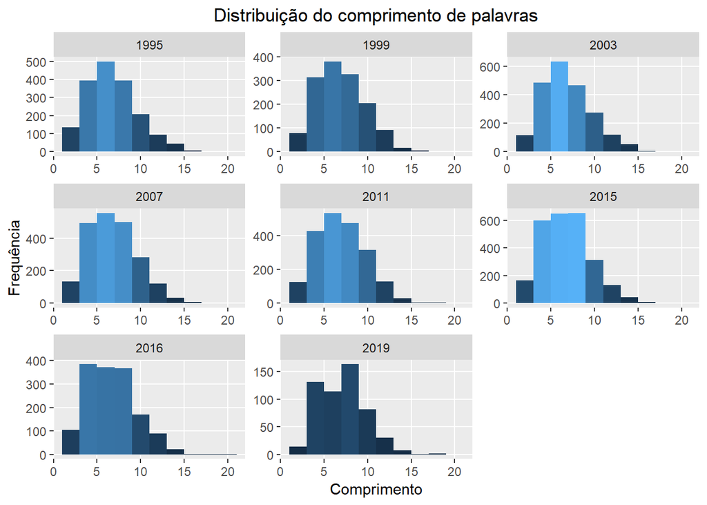

```r
# word length dist por doc


word_lengths %>%
  ggplot(aes(word_length, fill = ano),
    binwidth = 1
  ) +
  geom_histogram(aes(fill = ..count..),
    breaks = seq(1, max(word_lengths$word_length), by = 2),
    show.legend = FALSE
  ) +
  facet_wrap(~ano, scales = "free") +
  labs(x = "Comprimento", y = "Frequência") +
  ggtitle("Distribuição do comprimento de palavras") + theme(
    plot.title = element_text(hjust = 0.5),
    panel.grid.minor = element_blank()
  )
```

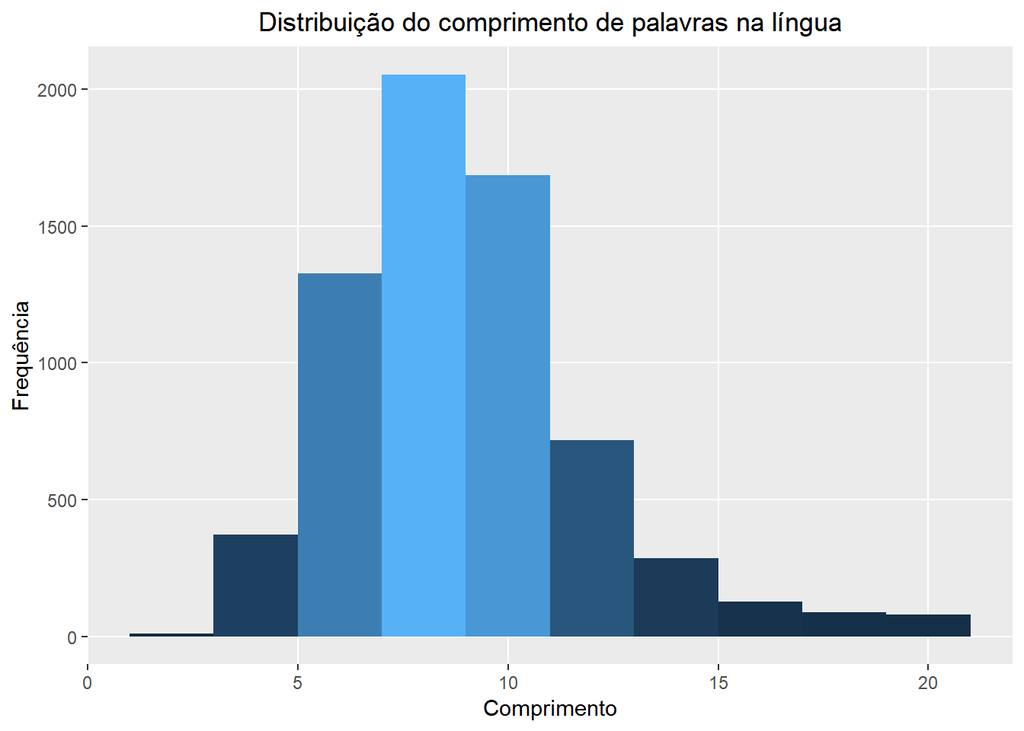

```r
## Comparando dentro da lingua usando a tabela sentilex

distpcomp <- sentiLex_lem_PT02 %>% as.data.frame() %>% select(term) %>% mutate(tam = nchar(term))

distpcomp %>%
  ggplot(aes(tam, fill = ano),
    binwidth = 1
  ) +
  geom_histogram(aes(fill = ..count..),
    breaks = seq(1, max(word_lengths$word_length), by = 2),
    show.legend = FALSE
  ) +
  ggtitle("Distribuição do comprimento de palavras na língua") +
  labs(x = "Comprimento", y = "Frequência") +
  theme(
    plot.title = element_text(hjust = 0.5),
    panel.grid.minor = element_blank()
  )
```

As próximas perguntas que surgem naturalmente são quais palavras foram mais ditas e quando isso aconteceu. O gráfico a seguir mostra quais foram as palavras mais faladas no total e a sua distribuição por discurso.

**P.S**: O gráfico também fica bonito dividindo por presidente ;)

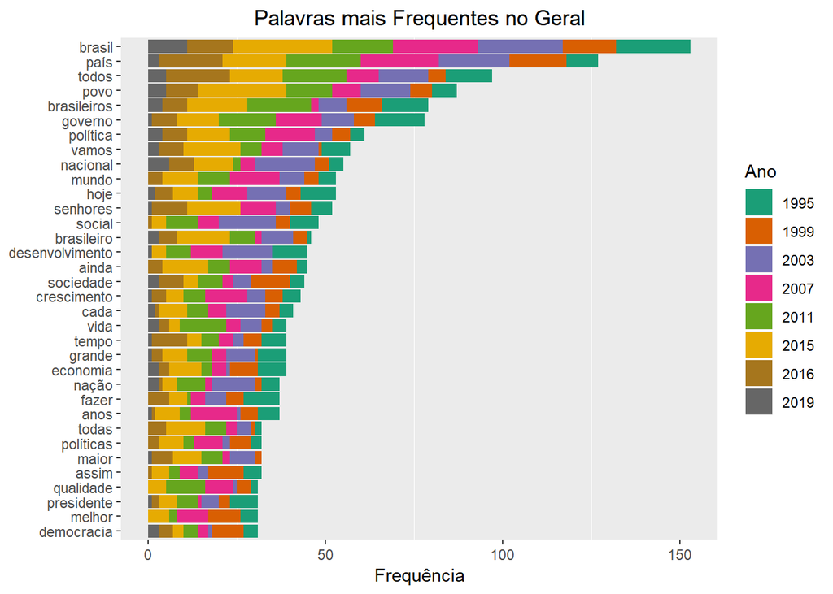

```r
####################

# total de ocorrencia de palavras
plot_total <- tf_frases %>%
  group_by(word) %>%
  mutate(total = sum(n), discs = length(docs)) %>%
  filter(str_count(word) > 3) %>%
  ungroup()

plot_total %>%
  mutate(word = reorder(word, total)) %>%
  filter(!(word %in% stp_wrds)) %>%
  group_by(word) %>%
  filter(total > 30) %>%
  ggplot() +
  geom_col(aes(word, n, fill = as.factor(docs))) +
  scale_fill_brewer(type = "qual", palette = "Dark2") +
  theme(
    plot.title = element_text(hjust = 0.5),
    panel.grid.major = element_blank()
  ) +
  xlab("") +
  ylab("Frequência") +
  ggtitle("Palavras mais Frequentes no Geral") +
  coord_flip() +
  theme(
    plot.subtitle = element_text(vjust = 1),
    plot.caption = element_text(vjust = 1)
  ) + labs(x = NULL, fill = "Ano")
```

```r
palavras_chave2 <- c("governo", "brasileiros", "mulheres")


radartab <- tidyfrase %>%
  filter(word %in% palavras_chave2) %>%
  count(word, presidas, sort = TRUE) %>%
  mutate(n = n + (presidas == "temer" | presidas == "bolsonaro") * n) %>%
  as.data.frame()

for (i in 1:nrow(radartab)) {
  if (radartab$presidas[i] == "bolsonaro" | radartab$presidas[i] == "temer") {
    radartab$n[i] <- 2 * radartab$n[i]
  }
}

# radartab<- radartab %>% mutate(percent = (as.numeric(n)/ 15) * 100 ) %>%
radartab <- radartab %>%
  spread(word, n) %>%
  select(presidas, governo, brasileiros, mulheres)

chartJSRadar(radartab,
  showToolTipLabel = FALSE,
  main = "Distribuição de Palavra por Presidente"
)
```

[interactive chart not shown]

Também mostramos as sete palavras mais faladas em cada discurso e por cada presidente e, em caso de empate, eliminamos arbitrariamente alguns dos ‘últimos’ elementos, usando a função `slice` unicamente para melhorar a vizualização. Aqui temos um exemplo de gráfico que, na divisão por presidente, não é estritamente nescessário multiplicar as métricas de Temer e Bolsonaro, uma vez que essas são computatas independentemente umas das outras. Aqui o fizemos, novamente por motivos estéticos. (experimente os efeitos de comentar as linhas indicadas abaixo)

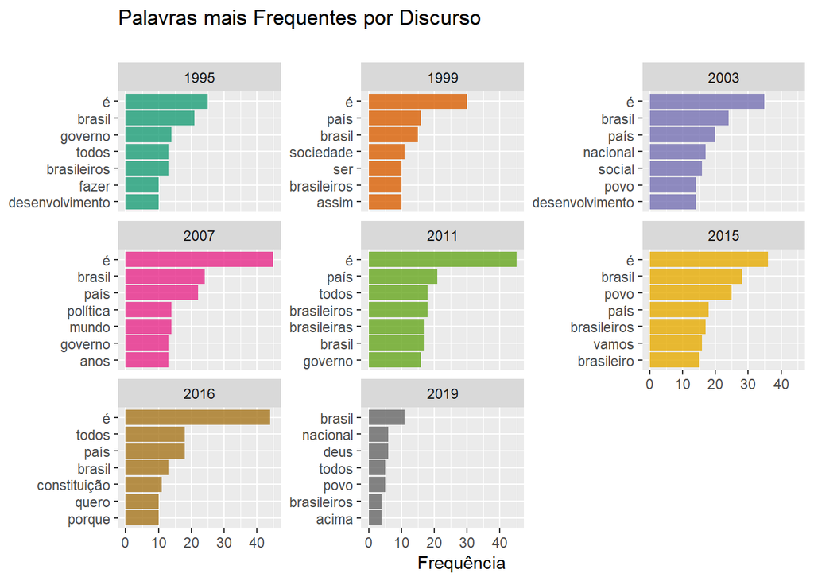

```r
# Palavras mais faladas por discurso
tidyfrase %>%
  group_by(docs) %>%
  count(word, docs, sort = TRUE) %>%
  top_n(7) %>% # Me comente
  slice(1:7) %>%
  ungroup() %>%
  mutate(term = reorder_within(word, n, docs)) %>%
  ggplot(aes(term, n, fill = as.factor(docs))) +
  geom_col(alpha = 0.8, show.legend = FALSE) +
  facet_wrap(~docs, scales = "free_y") +
  scale_fill_brewer(type = "qual", palette = "Dark2") +
  coord_flip() +
  scale_x_reordered() +
  labs(
    x = NULL, y = "Frequência",
    title = "Palavras mais Frequentes por Discurso",
    subtitle = " "
  )
```

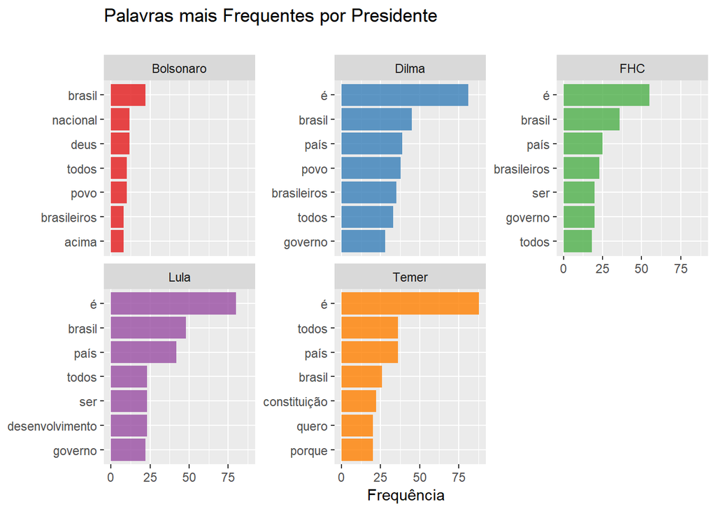

```r
# Palavras mais faladas por presidente
tidyfrase %>%
  group_by(presidas) %>%
  count(word, presidas, sort = TRUE) %>%
  mutate(n = n + (presidas == "temer" | presidas == "bolsonaro") * n) %>%
  top_n(7) %>% # Me comente também
  slice(1:7) %>%
  ungroup() %>%
  mutate(term = reorder_within(word, n, presidas)) %>%
  ggplot(aes(term, n, fill = as.factor(presidas))) +
  geom_col(alpha = 0.8, show.legend = FALSE) +
  facet_wrap(~presidas, scales = "free_y", labeller = labeller(presidas = c(bolsonaro = "Bolsonaro", dilma = "Dilma", fhc = "FHC", lula = "Lula", temer = "Temer"))) +
  scale_fill_brewer(type = "qual", palette = "Set1") +
  coord_flip() +
  scale_x_reordered() +
  labs(
    x = NULL, y = "Frequência",
    title = "Palavras mais Frequentes por Presidente",
    subtitle = " "
  )
```

De certa forma, os gráficos acima confirmam a nossa impressão ao olhar as primeiras nuvens de palavras: existem palavras que se repetem muitas vezes num discurso presidencial por natureza. Esse fato nos atrapalha na tarefa de identificar as diferenças entre cada instância. Para lidar com esse problema, usamos uma técnica muito simples e surpreendentemente ,comum em análise automatizada de textos, que é eliminar sumariamente esses termos, esperando que os próximos no ranking tragam informações relevantes. Além disso, eliminamos as palavras “é”, “assim” e “ainda”. Finalmente, vamos eliminar palavras com três letras ou menos.

```r
undesirable_words <- (((plot_total %>% select(word, n) %>% arrange(desc(n)))$word) %>% unique())[1:15]
undesirable_words <- c(as.character(undesirable_words), "é", "assim", "ainda")
```

Vejamos a seguir os efeitos que essas mudanças produzem nos nossos resultados:

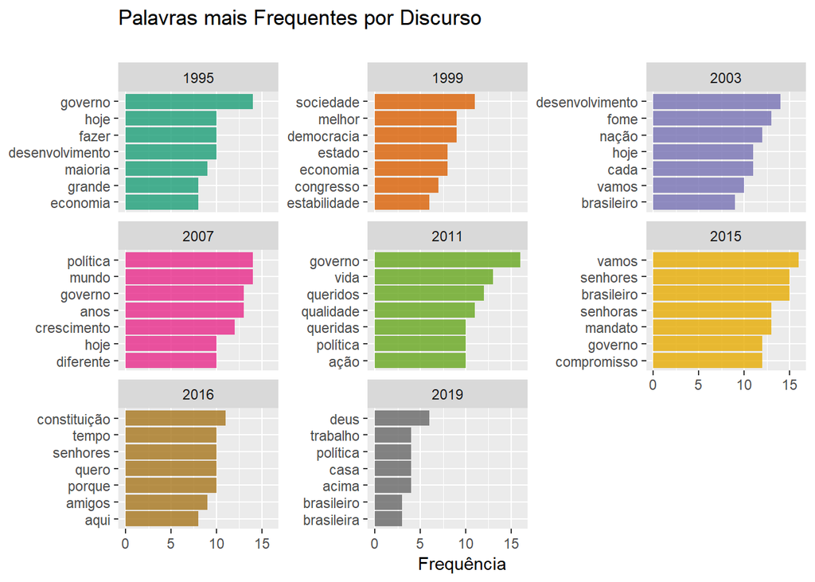

```r
# Palavras mais faladas por discurso
tidyfrase %>%
  filter(!(word %in% undesirable_words)) %>%
  filter(nchar(word) > 3) %>%
  group_by(docs) %>%
  count(word, docs, sort = TRUE) %>%
  top_n(7) %>% # Me comente
  slice(1:7) %>%
  ungroup() %>%
  mutate(term = reorder_within(word, n, docs)) %>%
  ggplot(aes(term, n, fill = as.factor(docs))) +
  geom_col(alpha = 0.8, show.legend = FALSE) +
  facet_wrap(~docs, scales = "free_y") +
  scale_fill_brewer(type = "qual", palette = "Dark2") +
  coord_flip() +
  scale_x_reordered() +
  labs(
    x = NULL, y = "Frequência",
    title = "Palavras mais Frequentes por Discurso",
    subtitle = " "
  )
```

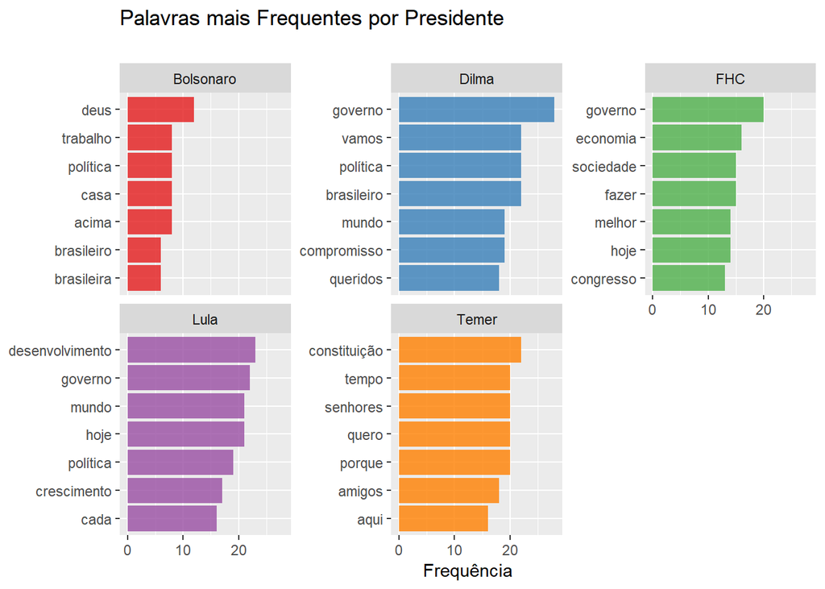

```r
# Palavras mais faladas por presidente

tidyfrase %>%
  filter(!(word %in% undesirable_words)) %>%
  filter(nchar(word) > 3) %>%
  group_by(presidas) %>%
  count(word, presidas, sort = TRUE) %>%
  mutate(n = n + (presidas == "temer" | presidas == "bolsonaro") * n) %>%
  top_n(7) %>%
  slice(1:7) %>%
  ungroup() %>%
  mutate(term = reorder_within(word, n, presidas)) %>%
  ggplot(aes(term, n, fill = as.factor(presidas))) +
  geom_col(alpha = 0.8, show.legend = FALSE) +
  facet_wrap(~presidas, scales = "free_y", labeller = labeller(presidas = c(bolsonaro = "Bolsonaro", dilma = "Dilma", fhc = "FHC", lula = "Lula", temer = "Temer"))) +
  scale_fill_brewer(type = "qual", palette = "Set1") +
  coord_flip() +
  scale_x_reordered() +
  labs(
    x = NULL, y = "Frequência",
    title = "Palavras mais Frequentes por Presidente",
    subtitle = " "
  )
```

À primeira vista, parece que nossa última filtragem produziu resultados positivos em termos de informação. Adotaremos esse procedimento em muitos lugares daqui em diante.

## A Estatística TF-IDF

Finalmente chegou a hora de incorporar a estatística TF-IDF, que já citamos acima, na nossa análise. O TF-IDF de uma palavra em relação a um texto em um conjunto de documentos é dado pelo número de aparições dessa palavra no texto dividido pelo número de documentos em que a palavra aparece. O número de aparições de uma palavra idealmente indica sua importância dentro de um texto. Em contrapartida, o número de textos em que a palavra aparece indica a importância da palavra no contexto dos documentos. Sendo assim, essa medida quantifica o quão importante um palavra é para um texto em particular, dentro de um conjunto de documentos. Se temos um conjunto de $i=1,\cdots,n$ textos, então o TF-IDF da palavra $w$ no texto $i$ é dado por
$$T_i(w)=\frac{N_i(w)}{K(w)}.$$

Onde $N_i(w)$ é o número de vezes que a palavra $w$ aparece no texto $i$ e $K(w)$ é o número de documentos que contém $w$. Daqui pra frente, nos aproveitaremos dessa ideia das mais diversas formas. A maneira mais natural de usar o TF-IDF no nosso contexto é considerar que cada discurso é um documento, de modo que medimos as palavras relevantes em cada documento. Uma pequena variação dessa linha de pensamento se dá ao considerarmos cada presidente em si um documento, assim mensuramos a importância dada por cada pessoa aos termos.

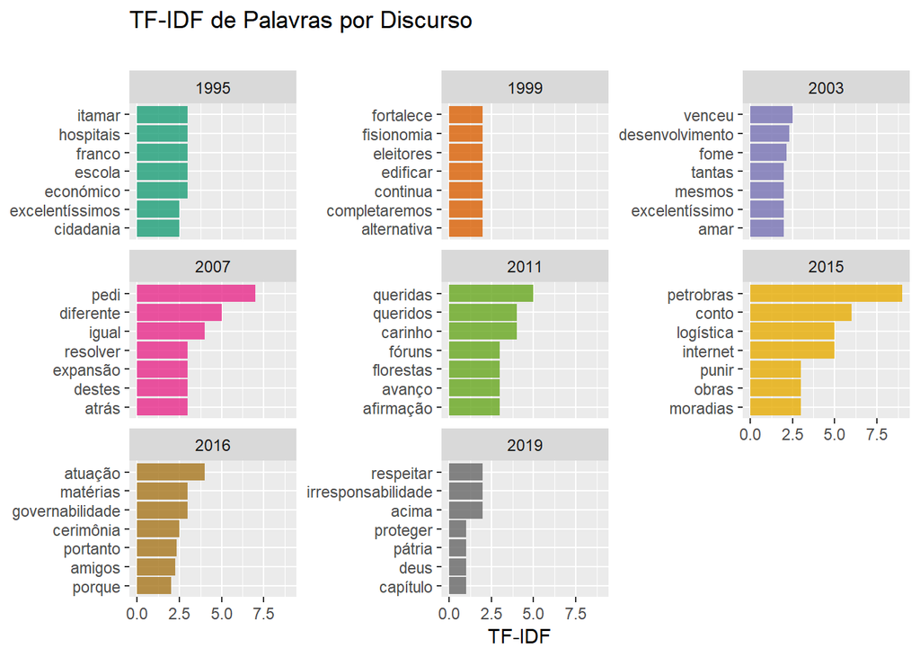

```r
## TF-IDF de PALAVRAS POR DISCURSO

tfrases2 <- tidyfrase %>%
  filter(!(word %in% undesirable_words)) %>%
  filter(nchar(word) > 3) %>%
  group_by(docs) %>%
  count(word, docs, sort = TRUE) %>%
  tf_idf_caseirao()


tfrases2 %>%
  top_n(7) %>%
  slice(1:7) %>%
  ungroup() %>%
  mutate(term = reorder_within(word, tf_idf, docs)) %>%
  ggplot(aes(term, tf_idf, fill = as.factor(docs))) +
  geom_col(alpha = 0.8, show.legend = FALSE) +
  scale_fill_brewer(type = "qual", palette = "Dark2") +
  facet_wrap(~docs, scales = "free_y") +
  coord_flip() +
  scale_x_reordered() +
  labs(
    x = NULL, y = "TF-IDF",
    title = "TF-IDF de Palavras por Discurso",
    subtitle = " "
  )
```

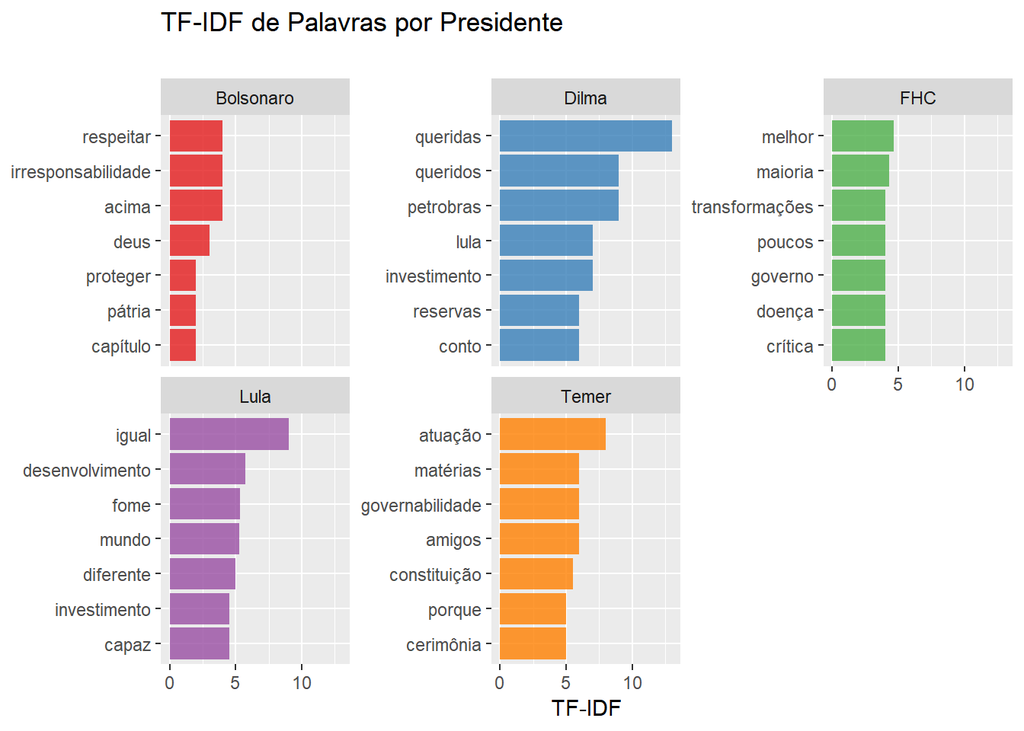

```r
# TF-IDF de PALAVRAS por presidente

tfrases <- tidyfrase %>%
  filter(!(word %in% undesirable_words)) %>%
  filter(nchar(word) > 3) %>%
  group_by(presidas) %>%
  count(word, presidas, sort = TRUE) %>%
  tf_idf_caseirao() %>%
  mutate(tf_idf = tf_idf + (presidas == "temer" | presidas == "bolsonaro") * tf_idf)



tfrases %>%
  top_n(7) %>%
  slice(1:7) %>%
  ungroup() %>%
  mutate(term = reorder_within(word, tf_idf, presidas)) %>%
  ggplot(aes(term, tf_idf, fill = as.factor(presidas))) +
  geom_col(alpha = 0.8, show.legend = FALSE) +
  facet_wrap(~presidas, scales = "free_y", labeller = labeller(presidas = c(bolsonaro = "Bolsonaro", dilma = "Dilma", fhc = "FHC", lula = "Lula", temer = "Temer"))) +
  scale_fill_brewer(type = "qual", palette = "Set1") +
  coord_flip() +
  scale_x_reordered() +
  labs(
    x = NULL, y = "TF-IDF",
    title = "TF-IDF de Palavras por Presidente",
    subtitle = " "
  )
```

Em seguida, fizemos uma grande variedade de nuvens de palavras utilizando vários tipos de nuvens de palavras baseadas no TF-IDF das palavras, não incluímos esses resultados no texto para economizar um pouco da paciência do leitor.

```r
# #Nuvem - numero abs - presidas
#
# pres<-unique(tfrases$presidas)
# for(i in 1:length(pres)){
#   aux<-filter(as.data.frame(tfrases%>%ungroup()), presidas==pres[i])
#   aux<-arrange(aux, desc(tf_idf))
#   aux<- aux %>% group_by(presidas)
#   aux<- aux %>% top_n(15) %>% ungroup()
#   aux<-select(aux,word,tf_idf)
#   ggwordcloud2(aux) %>% print()
#
# }
#
#
# #Nuvem - desvio padrão - ano
#
# anos<-unique(tfrases2$docs)
# for(i in 1:length(anos)){
#   aux<-filter(as.data.frame(tfrases2%>%ungroup()), docs==anos[i])
#   aux<-arrange(aux, desc(tf_idf))
#   med<-mean(aux$tf_idf)
#   sd<- sd(aux$tf_idf)
#   aux<-aux %>% filter( tf_idf-med > 2*sd)
#   aux<-select(aux,word,tf_idf)
#   ggwordcloud2(aux) %>% print()
#
#   }
#
#
# #Nuvem - abs- ano
#
# anos<-unique(tfrases2$docs)
# for(i in 1:length(anos)){
#   aux<-filter(as.data.frame(tfrases2%>%ungroup()), docs==anos[i])
#   aux<-arrange(aux, desc(tf_idf))
#   aux<- aux %>% top_n(15)
#   aux<-select(aux,word,tf_idf)
#   ggwordcloud2(aux) %>% print()
#
#   }
#
```

A partir de agora, teremos várias ramificações na nossa análise. A ordenação dos tópicos daqui em diante foi projetada unicamente para preservar a harmonia entre as variáveis do código.

## Bigramas

Acabamos de realizar uma análise descritiva relativamente simples dos discursos de posse desde 1995. Apesar disso, há de se destacar que toda a análise foi baseada apenas na frequência de palavras isoladas. O problema mais básico que surge nesse tipo de abordagem é desconsiderar completamente o contexto em que as palavras se encontram. Numa tentativa de lidar parcialmente com esse incoveniente, vamos agora análisar bigramas, que são conjuntos de duas palavras consecutivas em um texto. Em primeiro lugar vamos arrumar nossos dados, note que vamos usar a função `unnest_tokens` assim como no início. Sem ela nosso trabalho seria bem mais difícil!

```r
## Bigramas - Organizando as Tabelas

bigrams <- tab_frase %>% select(frases, docs, presidas) %>% mutate(nfrase = row_number()) %>% unnest_tokens(bigram, frases, token = "ngrams", n = 2)

bigrams_separated <- bigrams %>%
  separate(bigram, c("word1", "word2"), sep = " ")

## ADICIONAR OUTRAS PALAVRAS PARA FILTRAR????
bigrams_filter <- bigrams_separated %>%
  filter(!(word1 %in% undesirable_words)) %>%
  filter(nchar(word1) > 3) %>%
  filter(!(word2 %in% undesirable_words)) %>%
  filter(nchar(word2) > 3) %>%
  filter(!(word1 %in% stp_wrds)) %>%
  filter(!(word2 %in% stp_wrds))


bigrams_pres <- bigrams_filter %>%
  filter(word1 != word2) %>%
  unite(word, word1, word2, sep = " ", remove = FALSE) %>%
  count(word, presidas, sort = TRUE) %>%
  group_by(presidas)

bigrams_discursos <- bigrams_filter %>%
  filter(word1 != word2) %>%
  unite(word, word1, word2, sep = " ", remove = FALSE) %>%
  count(word, docs, sort = TRUE) %>%
  group_by(docs)
```

Agora, vamos mostar gráficos de frequência de bigramas dividindo por discurso e presidente, exatamente como fizemos para palavras isoladas.

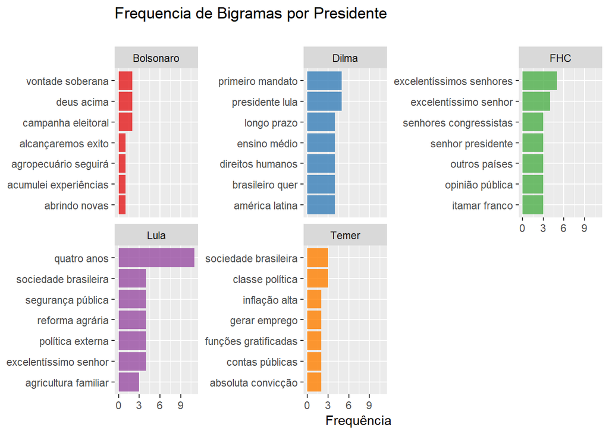

```r
## Primeiros GRAFICOS - Frequencia de bigramas

bigrams_pres %>%
  top_n(7) %>%
  slice(1:7) %>%
  ungroup() %>%
  mutate(term = reorder_within(word, n, presidas)) %>%
  ggplot(aes(term, n, fill = as.factor(presidas))) +
  geom_col(alpha = 0.8, show.legend = FALSE) +
  facet_wrap(~presidas, scales = "free_y", labeller = labeller(presidas = c(bolsonaro = "Bolsonaro", dilma = "Dilma", fhc = "FHC", lula = "Lula", temer = "Temer"))) +
  scale_fill_brewer(type = "qual", palette = "Set1") +
  coord_flip() +
  scale_x_reordered() +
  labs(
    x = NULL, y = "Frequência",
    title = "Frequencia de Bigramas por Presidente",
    subtitle = " "
  )
```

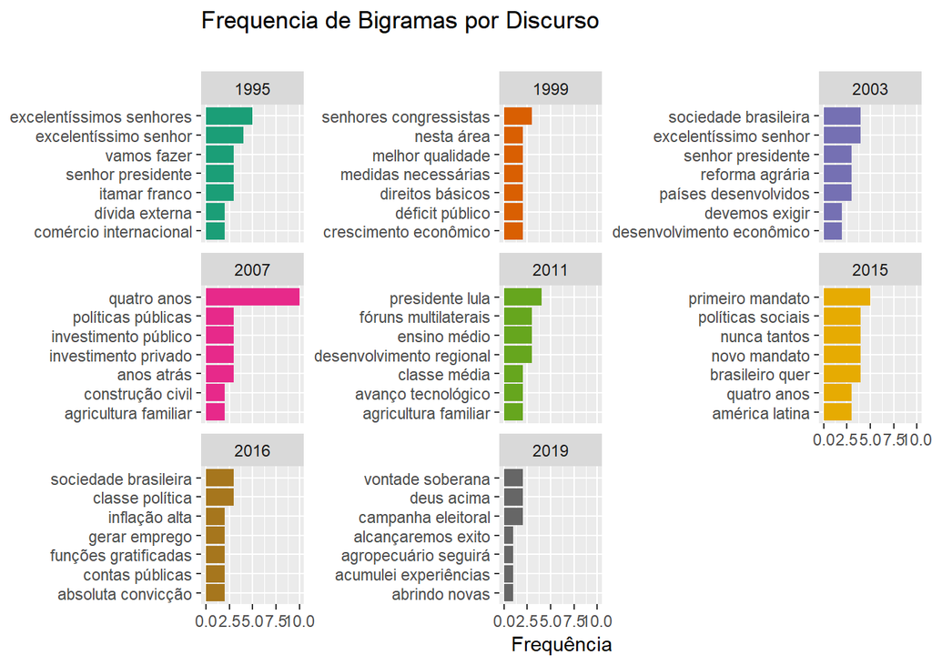

```r
bigrams_discursos %>%
  top_n(7) %>%
  slice(1:7) %>%
  ungroup() %>%
  mutate(term = reorder_within(word, n, docs)) %>%
  ggplot(aes(term, n, fill = as.factor(docs))) +
  scale_fill_brewer(type = "qual", palette = "Dark2") +
  geom_col(show.legend = FALSE) +
  facet_wrap(~docs, scales = "free_y") +
  coord_flip() +
  scale_x_reordered() +
  labs(
    x = NULL, y = "Frequência",
    title = "Frequencia de Bigramas por Discurso",
    subtitle = " "
  )
```

Também decidimos calcular o TF-IDF de bigramas num texto, por que não? A adaptação que fizemos no TF-IDF é bem pequena. Apenas utilizamos a frequência de bigramas ao invés da frequência de palavras.

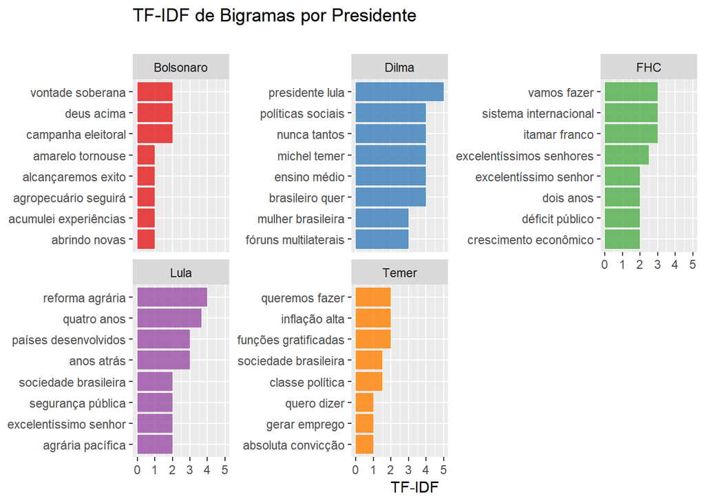

```r
## MAIS GRAFICOS - TD-IDF de Bigramas- pq nao?

bigramspres_tdidf <- bigrams_pres %>% tf_idf_caseirao()

bigramsdoc_tdidf <- bigrams_discursos %>% tf_idf_caseirao()


## GRAFICO BIGRAMAS-TF-IDF PRESIDENTE
bigramspres_tdidf %>%
  top_n(8) %>%
  slice(1:8) %>%
  ungroup() %>%
  mutate(term = reorder_within(word, tf_idf, presidas)) %>%
  ggplot(aes(term, tf_idf, fill = as.factor(presidas))) +
  geom_col(alpha = 0.8, show.legend = FALSE) +
  facet_wrap(~presidas, scales = "free_y", labeller = labeller(presidas = c(bolsonaro = "Bolsonaro", dilma = "Dilma", fhc = "FHC", lula = "Lula", temer = "Temer"))) +
  scale_fill_brewer(type = "qual", palette = "Set1") +
  coord_flip() +
  scale_x_reordered() +
  labs(
    x = NULL, y = "TF-IDF",
    title = "TF-IDF de Bigramas por Presidente",
    subtitle = ""
  )
```

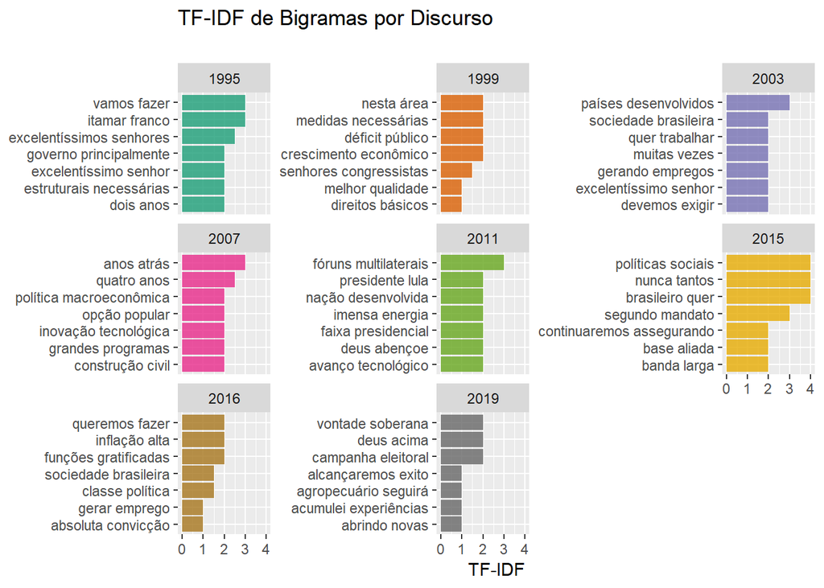

```r
## GRAFICO BIGRAMAS-TD-IDF DISCURSO
bigramsdoc_tdidf %>%
  top_n(7) %>%
  slice(1:7) %>%
  ungroup() %>%
  mutate(
    term = reorder_within(word, tf_idf, docs)
  ) %>%
  ggplot(aes(term, tf_idf, fill = as.factor(docs))) +
  geom_col(alpha = 0.8, show.legend = FALSE) +
  facet_wrap(~docs, scales = "free_y") +
  scale_fill_brewer(type = "qual", palette = "Dark2") +
  coord_flip() +
  scale_x_reordered() +
  labs(
    x = NULL, y = "TF-IDF",
    title = "TF-IDF de Bigramas por Discurso",
    subtitle = " "
  )
```

## Graf(ic)os

[Grafos](https://www.ime.usp.br/~yw/2018/grafinhos/aulas/cap1-new.pdf) são uma excelente maneira de se vizualizar conexões entre objetos. Existe uma infinidade de possibilidades ao se representar dados desse modo. Pra começo de conversa, temos que escolher quem são os vértices e arestas do nosso grafo. Em segundo lugar, é preciso escolher o que significa dois objetos estarem conectados. Daí pra frente, existe um oceano de possibilidades: podemos decidir se existem ligações mais fortes que outras, se há direção ou simetria nas mesmas, se podemos conectar mais de dois vértices de uma só vez, entre tantas outras. No nosso contexto, duas das perguntas que podemos tentar responder com grafos incluem:

1. Considerando palavras como vértices e dado um conjunto de palavras-chave, quais são as palavras que mais aparecem associadas a elas? Nesse caso podemos, por exemplo, adotar a força da conexão entre duas palavras como a quantidade de bigramas em que duas palavras estão pareadas. Outra possibilidade seria calcular a força da conexão entre duas palavras como a razão entre o número de vezes em que cada palavra aparece versus o número de vezes que ela está pareada com a outra. Assim teríamos uma nova adaptação do TF-IDF para bigramaas.
2. Considerando presidentes ou discursos como vértices, qual é o nível de similaridade entre duas instâncias? Nesse caso, claramente teremos arestas com valores correspondentes à similaridade calculada entre dois textos. Na sequência discutiremos um pouco mais sobre como obter um valor númerico que represente semelhança entre documentos.

Em seguida iremos utilizar a biblioteca `igraph` para transformar um `data.frame` num grafo e o pacote `ggraph` para nossas vizualizações.

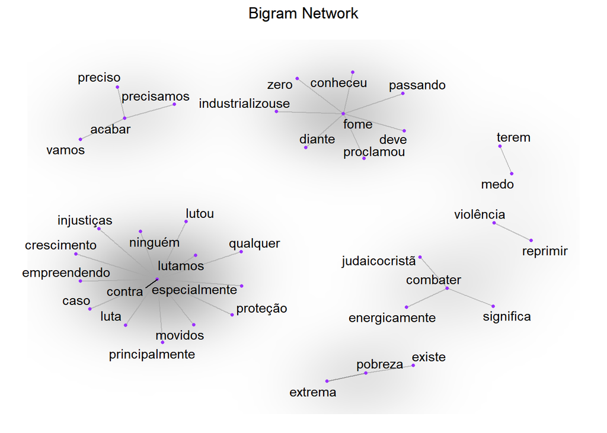

```r
## GRAFO DE BIGRAMAS

palavras_chave <- c("acabar", "diminuir", "combater", "erradicar", "contra", "não", "pobreza", "violência", "fome", "medo")

bigrams_chave <- bigrams_separated %>%
  filter(word1 %in% palavras_chave | word2 %in% palavras_chave) %>%
  count(word1, word2, sort = TRUE) %>%
  filter(!(word1 %in% stp_wrds | word2 %in% stp_wrds)) %>% ## VAI DE MORGAN CARAI
  filter(!(word1 %in% undesirable_words | word2 %in% undesirable_words)) %>%
  mutate(contribution = n) %>% # DA PRA FAZER UM ÍNDICE MAIS FERA AQUI
  arrange(desc(abs(contribution))) %>%
  group_by(word1) %>%
  slice(seq_len(40)) %>%
  arrange(word1, desc(contribution)) %>%
  ungroup()

bigram_graph <- bigrams_chave %>%
  graph_from_data_frame() # From `igraph`

set.seed(133)

a <- grid::arrow(type = "closed", length = unit(.15, "inches"))

ggraph(bigram_graph, layout = "fr") +
  geom_edge_link(alpha = .25) +
  geom_edge_density(aes(fill = n)) +
  geom_node_point(color = "purple1", size = 1) + # Purple for Prince!
  geom_node_text(aes(label = name), repel = TRUE) +
  theme_void() + theme(
    legend.position = "none",
    plot.title = element_text(hjust = 0.5)
  ) +
  ggtitle("Bigram Network")
```